# Forecasting project 2

2023-05-13

# Introduction

In 2020, the COVID19 pandemic transformed our lives and forced us to imagine new ways of working by limiting face to face interactions and contact. Since then, we haven’t stopped imagining new ways of communication and transportation. In fact many new services were born. For example, video conferencing tools such as Zoom allowed us to limit face to face interactions by performing meetings online whereas food delivery services allowed us to order food from restaurants that had to close doors due to social distancing rules. Tourism was also strongly impacted due to the effort of containing the virus and limiting its spread. It had a drastic effect on the airline industry since people weren’t able to travel for tourism anymore. Business travel were also drastically reduced because face-to-face meetings were moved online due to social distancing.

## Today’s challenges

In 2023, the amount of flights after the pandemic is back at its pre-pandemic levels. In fact, tourism and business travels are allowed again. However, airlines are facing many new challenges due to other external economical and political factors. The first problem that airlines are facing is the predictability of the demand. In fact due to economical factors such as inflation and increasing costs of goods, customers have more difficulty affording flights. Another challenge that airlines are facing is the unpredictability of supply chain for the repair parts of aircrafts. In fact, COVID 19 started a global problem of shortage of semi-conductors which are very used in modern aviation. The last problem that airlines are facing is the shortage of trained workforce. In fact, because the pandemic forced massive layoffs because of limitations of air traffic, many workers had to reconvert themselves in new professions and now that the demand is back, airlines are struggling filling all the needed jobs to respond to the demand.

## Scope of our work

To draft a solution to these challenges, we are going to analyze daily air traffic data from and to Switzerland in order to predict the amount of flight depending on the weather data in Switzerland and global crude oil prices. By predicting the amount of flights based on seasonality and patterns, airlines should be able to better predict the amount of workers needed and the amount of repair parts needed to maintain the aircrafts.

## What is Brent crude oil and why use it

Brent crude oil is a type of crude oil that is extracted from the North Sea and is one of the major benchmark prices for purchases of oil worldwide. Brent crude oil is light, sweet crude oil that is widely used for production of gasoline and middle distillates. It is named after the Brent goose, which is a common sight in the North Sea. Brent crude oil is traded on the Intercontinental Exchange (ICE) and its price is influenced by a variety of factors, including global supply and demand, geopolitical events, and economic factors.

More specifically, the price of Brent crude oil impacts the price of airplane transportation fuel, as it is one of the main components used in the production of jet fuel. Fluctuations in the price of Brent crude oil can affect the cost of manufacturing jet fuel, which in turn can impact the price of airplane tickets. We assume that if the price of the airplane ticktets is affected, then the demand for flights will also be affected. This is what we are aiming to investigate.

# Data cleaning

```r
#Flights data
data_2020 <- read.csv("data/2020-States.csv")
data_2021 <- read.csv("data/2021-States.csv")
data_2022 <- read.csv("data/2022-States.csv")
data_2023 <- read.csv("data/2023-States.csv")

#Merge all flights datasets together
data_2019 <- select(data_2020, Entity, Day.2019, Flights.2019..Reference.) %>% rename(Day = Day.2019, Flights = Flights.2019..Reference.)
data_2020 <- select(data_2020, Entity, Day, Flights)
data_2021 <- select(data_2021, Entity, Day, Flights)
data_2022 <- select(data_2022, Entity, Day, Flights)
data_2023 <- select(data_2023, Entity, Day, Flights)
data_all_years <- rbind(data_2019, data_2020, data_2021, data_2022, data_2023)

#Select only data where country == switzerland
flights <- data_all_years[data_all_years$Entity == 'Switzerland',]
flights$year_month = format(as.Date(flights$Day), "%Y-%m")

flights <- flights %>% select(Day,Flights) %>% set_names(c("Date", "Flights"))

#Convert the "Date" column to a date format:
#flights$Date <- parse_date_time(flights$Date, orders = c("%d-%b-%y", "%b %d, %Y"))
flights <- flights %>% mutate(Date = as.Date(Date, format = "%Y-%m-%d"))

#This shows that date is correctly converted to date type
str(flights)
```

```
## 'data.frame':    1763 obs. of  2 variables:
##  $ Date   : Date, format: "2019-01-02" "2019-01-03" ...
##  $ Flights: int  1290 1292 1415 1330 1398 1323 1111 1156 1165 1355 ...
```

```r
#there are a bunch of duplicated rows, i guess because of the way the data was imported?
duplicates(flights)
```

```
## Using `Date` as index variable.
```

```
## # A tibble: 372 × 2
##    Date       Flights
##    <date>       <int>
##  1 2020-01-01     981
##  2 2020-01-02    1293
##  3 2020-01-01     981
##  4 2020-01-02    1293
##  5 2021-10-01    1171
##  6 2021-10-02     983
##  7 2021-10-03    1079
##  8 2021-10-04    1047
##  9 2021-10-05     814
## 10 2021-10-06     842
## # ℹ 362 more rows
```

```r
#This will remove all the duplicated rows, and only keep one of them
flights <- flights %>%
  distinct()

#now there's no more duplicates
duplicates(flights)
```

```
## Using `Date` as index variable.
```

```
## # A tibble: 0 × 2
## # ℹ 2 variables: Date <date>, Flights <int>
```

```r
#Weather data
weather <- read_excel("data/switzerland weather.xlsx")

#Select appropriate columns (which covariates we will use)

weather <- weather %>% select(datetime,temp, precip, snow, windspeed, visibility, humidity)

#change column names to match with other datasets
colnames(weather)[1] <- "Date"

#Convert the "Date" column to a date format: (Previous type was POSIXct first time i'm seeing that)
#weather$Date <- parse_date_time(weather$Date, orders = c("%d-%b-%y", "%b %d, %Y"))
weather <- weather %>% mutate(Date = as.Date(Date))

#Some summary statistics for all columns
#weather %>% dfSummary(style = "grid")

str(weather)
```

```
## tibble [1,581 × 7] (S3: tbl_df/tbl/data.frame)
##  $ Date      : Date[1:1581], format: "2019-01-01" "2019-01-02" ...
##  $ temp      : num [1:1581] 3.8 1.5 -1.8 -1.4 -1.2 1.3 1.4 2.1 0.2 -1.3 ...
##  $ precip    : num [1:1581] 0 1.28 0 0 1.53 ...
##  $ snow      : num [1:1581] 0 0 0 0 0 0 0.2 0.1 0.9 0.4 ...
##  $ windspeed : num [1:1581] 7.6 9.6 18.5 17.3 8.4 7.1 8.5 18.5 11.9 10.5 ...
##  $ visibility: num [1:1581] 5 4.7 10 8 5.7 10 8.3 7.7 1 3.7 ...
##  $ humidity  : num [1:1581] 90.2 79.1 76.3 73.7 90 89.6 87.3 84.8 89.1 90.3 ...
```

```r
#There are no duplicates here
duplicates(weather)
```

```
## Using `Date` as index variable.
```

```
## # A tibble: 0 × 7
## # ℹ 7 variables: Date <date>, temp <dbl>, precip <dbl>, snow <dbl>,
## #   windspeed <dbl>, visibility <dbl>, humidity <dbl>
```

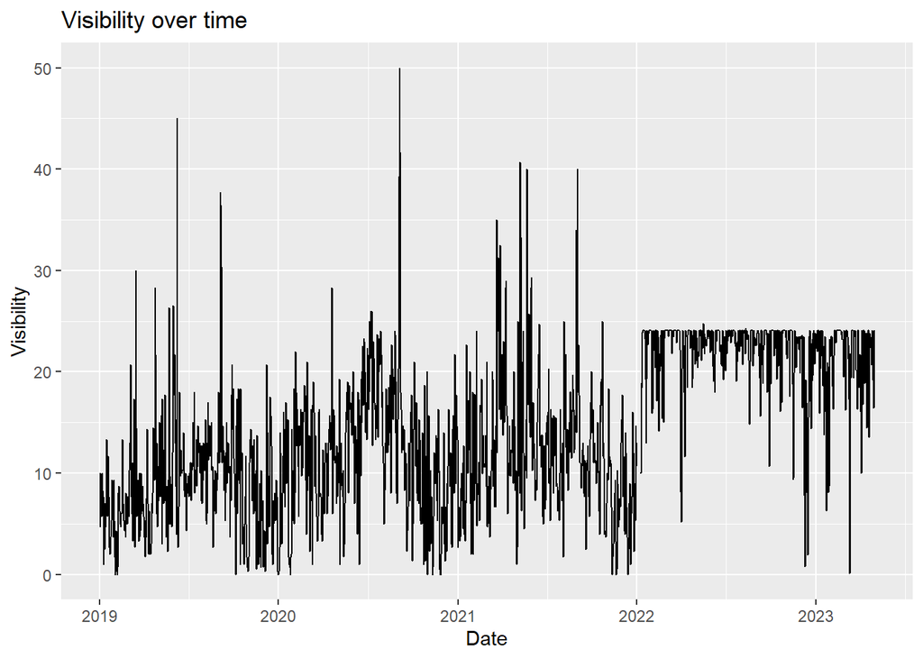

```r
#any(is.na(weather))

#visibility data for 2022-2023 looks very sus
ggplot(weather, aes(x = Date, y = visibility)) +
  geom_line() +
  labs(title = "Visibility over time", x = "Date", y = "Visibility")
```

```r
#Oil data

oil <- read.csv("data/BrentOilPrices.csv")

#Check for NA's, there's none
#sum(is.na(oil))

#Convert the "Date" column to a date format:
oil$Date <- parse_date_time(oil$Date, orders = c("%d-%b-%y", "%b %d, %Y"))

#Convert data to date type
oil <- oil %>% mutate(Date = as.Date(Date))

#check it's of the right type
str(oil)
```

```
## 'data.frame':    9011 obs. of  2 variables:
##  $ Date : Date, format: "1987-05-20" "1987-05-21" ...
##  $ Price: num  18.6 18.4 18.6 18.6 18.6 ...
```

```r
#Summary statistics
oil %>% dfSummary(style = "grid")
```

```
## Data Frame Summary
## oil
## Dimensions: 9011 x 2
## Duplicates: 0
##
## +----+-----------+-------------------------+----------------------+---------------------+----------+---------+
## | No | Variable  | Stats / Values          | Freqs (% of Valid)   | Graph               | Valid    | Missing |
## +====+===========+=========================+======================+=====================+==========+=========+
## | 1  | Date      | min : 1987-05-20        | 9011 distinct values | : : : : : : : : : : | 9011     | 0       |
## |    | [Date]    | med : 2005-02-02        |                      | : : : : : : : : : : | (100.0%) | (0.0%)  |
## |    |           | max : 2022-11-14        |                      | : : : : : : : : : : |          |         |
## |    |           | range : 35y 5m 25d      |                      | : : : : : : : : : : |          |         |
## |    |           |                         |                      | : : : : : : : : : : |          |         |
## +----+-----------+-------------------------+----------------------+---------------------+----------+---------+
## | 2  | Price     | Mean (sd) : 48.4 (32.9) | 5015 distinct values | :                   | 9011     | 0       |
## |    | [numeric] | min < med < max:        |                      | :                   | (100.0%) | (0.0%)  |
## |    |           | 9.1 < 38.6 < 143.9      |                      | :                   |          |         |
## |    |           | IQR (CV) : 51 (0.7)     |                      | : : . . .     .     |          |         |
## |    |           |                         |                      | : : : : : . . : .   |          |         |
## +----+-----------+-------------------------+----------------------+---------------------+----------+---------+
```

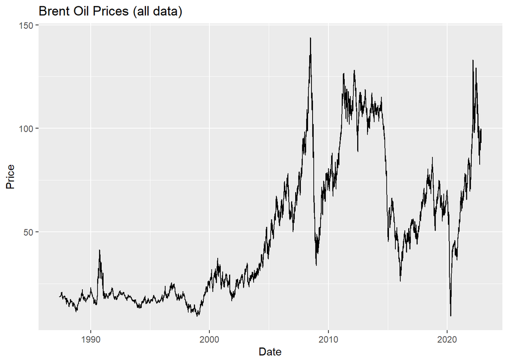

```r
#Plot the time series
ggplot(oil, aes(x = Date, y = Price)) +
  geom_line() +
  labs(title = "Brent Oil Prices (all data)", x = "Date", y = "Price")
```

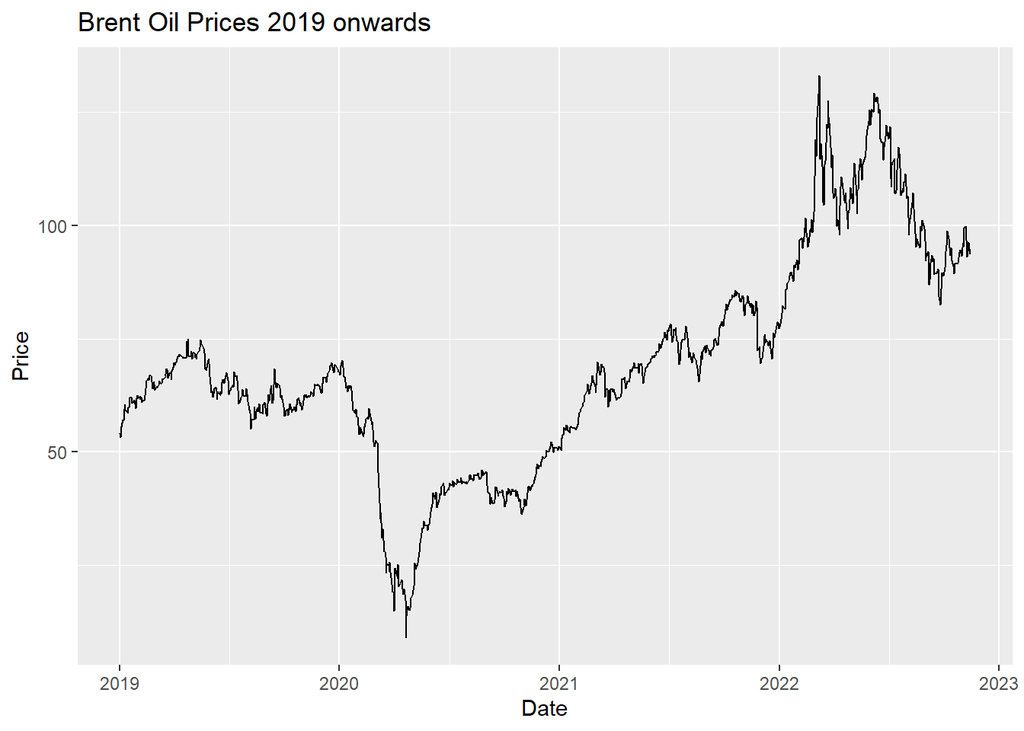

```r
#convert to tsibble object -> NOT YET
#oil <- oil %>%
  #mutate(Date = yearmonth(Date)) %>% #need to do this before converting to get proper format
  #as_tsibble(index = Date)

#Select appropriate dates
oil <- oil %>%
  mutate(Date = as.Date(Date)) %>%
  filter(Date > as.Date("2019-01-01"))

#Plot the time series
ggplot(oil, aes(x = Date, y = Price)) +
  geom_line() +
  labs(title = "Brent Oil Prices 2019 onwards", x = "Date", y = "Price")
```

```r
#I do the following, becauase I realized that even though there are not explicit NA's, there are some date rows missing, and I need to create them...


# create a complete sequence of dates from the minimum to maximum date
all_dates <- seq(min(oil$Date), max(oil$Date), by = "day")

# use complete() to create rows for the missing dates
oil <- oil %>%
  complete(Date = all_dates)

# replace missing prices with NA
oil$Price[is.na(oil$Price)] <- NA

#There are 426 missing values now that I have completed the oil dataset...
sum(is.na(oil))
```

```
## [1] 426
```

```r
#there are no duplicates here
duplicates(oil)
```

```
## Using `Date` as index variable.
```

```
## # A tibble: 0 × 2
## # ℹ 2 variables: Date <date>, Price <dbl>
```

```r
#Trying with another oil dataset... THIS WAS EVEN WORSE

#newoil <- read.csv('data/crudeoil.csv')

#Converting date column to date type + format
#newoil <- newoil %>%
#  mutate(Date = as.Date(Date, format = "%m/%d/%Y"))

#Select relevant columns
#newoil <- newoil %>% select(Date,Close.Last)

#Select relevant dates
#newoil <- newoil %>%
#  mutate(Date = as.Date(Date)) %>%
#  filter(Date > as.Date("2019-01-01"))

#Plot the time series
#ggplot(newoil, aes(x = Date, y = Close.Last)) +
#  geom_line() +
#  labs(title = "Oil Prices 2019 onwards", x = "Date", y = "Price")

#Check for NA's -> There are no NA's for the moment
#sum(is.na(newoil))
```

## Merging the datasets

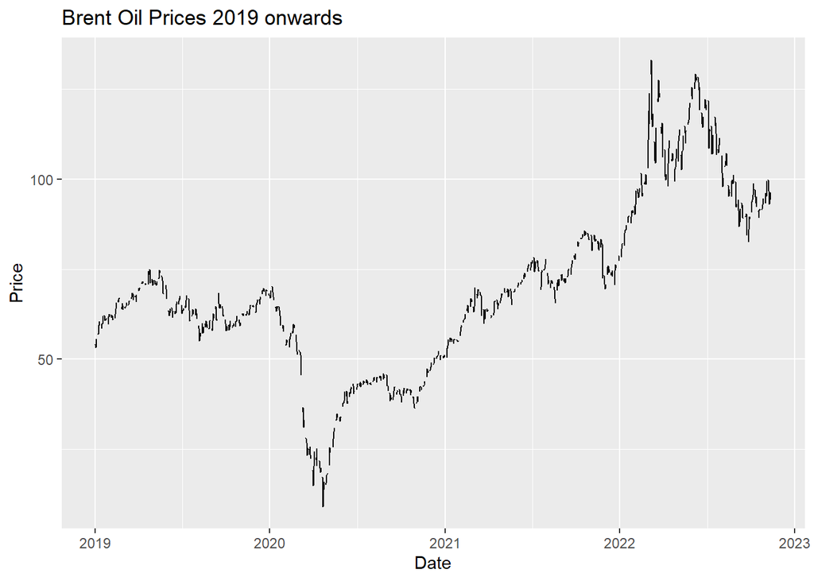

```r
#Merging datasets together
data <- flights %>%
  left_join(oil, by = "Date") %>%
  left_join(weather, by = "Date")

data <- data %>%
  filter(Date < as.Date("2022-11-14"))

#Convert to tsibble object
ts_data <- data %>%
  as_tsibble(index = Date)


#Plot the time series
ts_data %>% autoplot(Price) +
  labs(title = "Brent Oil Prices 2019 onwards", x = "Date", y = "Price")
```

```r
#Info on our variables
str(ts_data)
```

```
## tbl_ts [1,412 × 9] (S3: tbl_ts/tbl_df/tbl/data.frame)
##  $ Date      : Date[1:1412], format: "2019-01-02" "2019-01-03" ...
##  $ Flights   : int [1:1412] 1290 1292 1415 1330 1398 1323 1111 1156 1165 1355 ...
##  $ Price     : num [1:1412] 54.1 53.2 55.6 NA NA ...
##  $ temp      : num [1:1412] 1.5 -1.8 -1.4 -1.2 1.3 1.4 2.1 0.2 -1.3 -1.7 ...
##  $ precip    : num [1:1412] 1.28 0 0 1.533 0.004 ...
##  $ snow      : num [1:1412] 0 0 0 0 0 0.2 0.1 0.9 0.4 0.5 ...
##  $ windspeed : num [1:1412] 9.6 18.5 17.3 8.4 7.1 8.5 18.5 11.9 10.5 11.6 ...
##  $ visibility: num [1:1412] 4.7 10 8 5.7 10 8.3 7.7 1 3.7 2.5 ...
##  $ humidity  : num [1:1412] 79.1 76.3 73.7 90 89.6 87.3 84.8 89.1 90.3 85.8 ...
##  - attr(*, "key")= tibble [1 × 1] (S3: tbl_df/tbl/data.frame)
##   ..$ .rows: list<int> [1:1]
##   .. ..$ : int [1:1412] 1 2 3 4 5 6 7 8 9 10 ...
##   .. ..@ ptype: int(0)
##  - attr(*, "index")= chr "Date"
##   ..- attr(*, "ordered")= logi TRUE
##  - attr(*, "index2")= chr "Date"
##  - attr(*, "interval")= interval [1:1] 1D
##   ..@ .regular: logi TRUE
```

I discovered the imputeTS package, which includes various imputation methods, as well as some statistics for the missing values. Here are some of them:

```r
library(imputeTS)
```

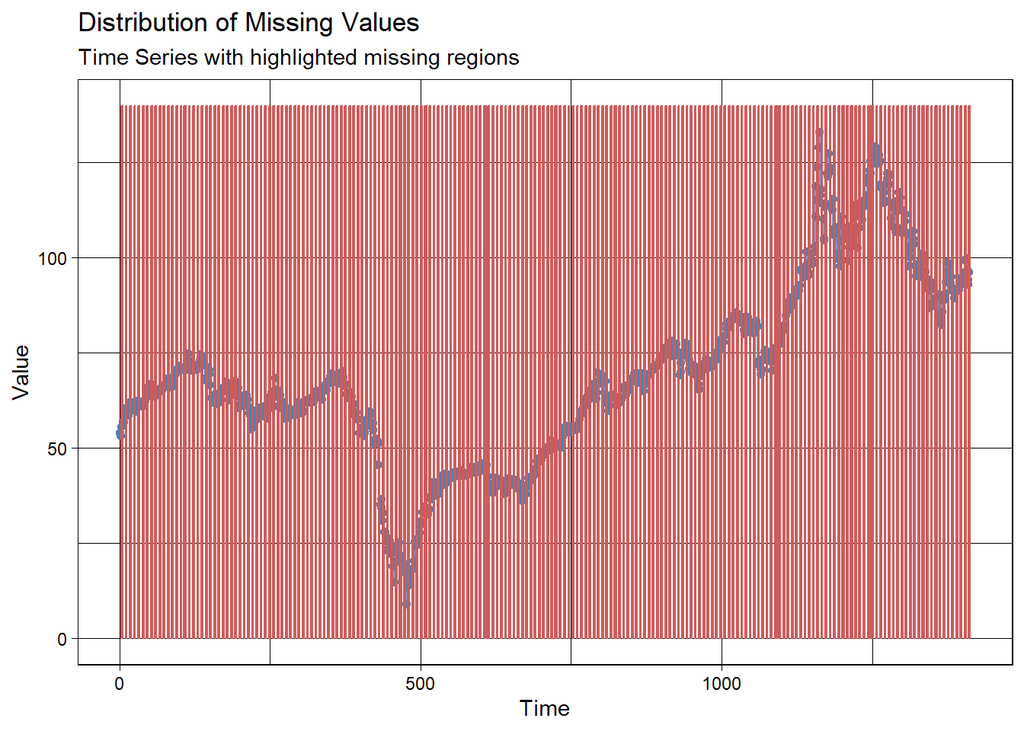

```r
#This graph looks terrible but it shows you all the missing data
ggplot_na_distribution(ts_data$Price)
```

```r
#missing data statistics -> actually quite useful to see what's going on
statsNA(ts_data$Price)
```

```
## [1] "Length of time series:"
## [1] 1412
## [1] "-------------------------"
## [1] "Number of Missing Values:"
## [1] 426
## [1] "-------------------------"
## [1] "Percentage of Missing Values:"
## [1] "30.2%"
## [1] "-------------------------"
## [1] "Number of Gaps:"
## [1] 203
## [1] "-------------------------"
## [1] "Average Gap Size:"
## [1] 2.098522
## [1] "-------------------------"
```

[output cut: 20 more lines]

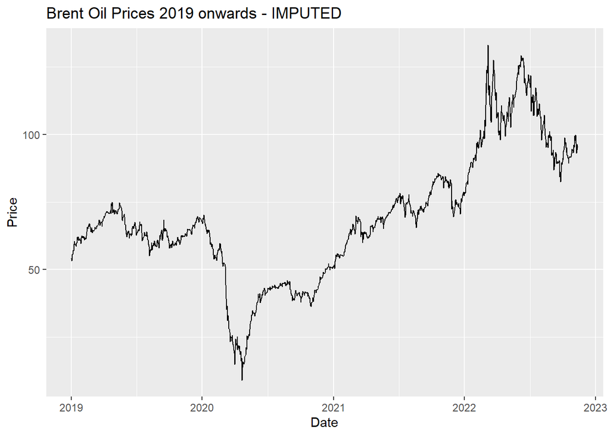

```r
#I'm choosingthe moving average method to impute the data.
ts_data$Price <- na_ma(ts_data$Price)

#Plot the time series
ts_data %>% autoplot(Price) +
  labs(title = "Brent Oil Prices 2019 onwards - IMPUTED", x = "Date", y = "Price")
```

In the imputeTS package, there are a lot of methods to impute the data, and after trying some we decided to stick with the weighted moving average. This is because most frequently (185 times) the gap is only 2 NA values long. There are 13 cases where the gap is 3 NA’s long, and only 4 cases where the gap is 4 NA’s long. This means that using the weighted moving average is providing a very good approximation of the price data.

If the gaps were longer and the NA’s were all concentrated in one big area, then we would consider using other imputation methods, but this is really not the case. The missing values seem to be spread all over the data, so the moving weighted averate seems to be doing a great job.

Finally, let’s check to see if there’s any missing data after imputation

```r
#Final check
any(is.na(ts_data)) #seems there are still some NA's
```

```
## [1] TRUE
```

```r
# Identify rows with missing values
na_rows <- !complete.cases(ts_data)

# Print rows with missing values
ts_data[na_rows,]
```

```
## # A tsibble: 6 x 9 [1D]
##   Date       Flights Price  temp precip  snow windspeed visibility humidity
##   <date>       <int> <dbl> <dbl>  <dbl> <dbl>     <dbl>      <dbl>    <dbl>
## 1 2022-01-02    1344  78.7   4.1  0         0       9.8         NA     81.6
## 2 2022-01-03    1118  78.2   9.9  0         0      15.1         NA     65.7
## 3 2022-01-04     913  79.4  11.1  2.95      0      29.2         NA     66.7
## 4 2022-01-05     837  80.6   1.5 15.8       0      12.4         NA     80.1
## 5 2022-01-06     888  82.0  -0.2  0         0       7.3         NA     78.7
## 6 2022-01-07     972  82.3  -1.3  0.937     0      11.7         NA     85.6
```

It looks like there are 6 rows with missing values in the visibility column. I will just use the same same function as previously to impute them.

```r
#I'm choosing the moving average method to impute the data.
ts_data$visibility <- na_ma(ts_data$visibility)

any(is.na(ts_data))
```

```
## [1] FALSE
```

Finally, I need to round the values to 2 decimals for Price and visibility

```r
ts_data$Price <- round(ts_data$Price, 2)
ts_data$visibility <- round(ts_data$visibility, 2)
```

# Exploratory data analysis

## Univariate analysis

In this first part of our EDA, we will explore each variable on its own, before looking at the relationship between different variables.

### Plots of each variable over time:

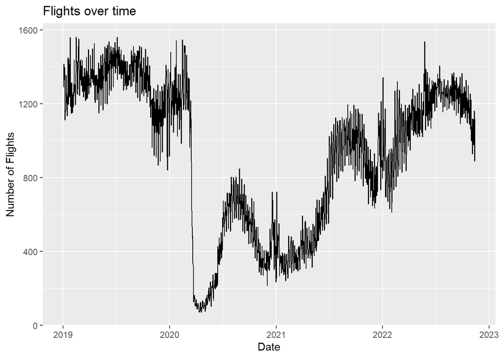

```r
#Flights plot
ts_data %>% autoplot(Flights) +
  labs(title = "Flights over time", x = "Date", y = "Number of Flights")
```

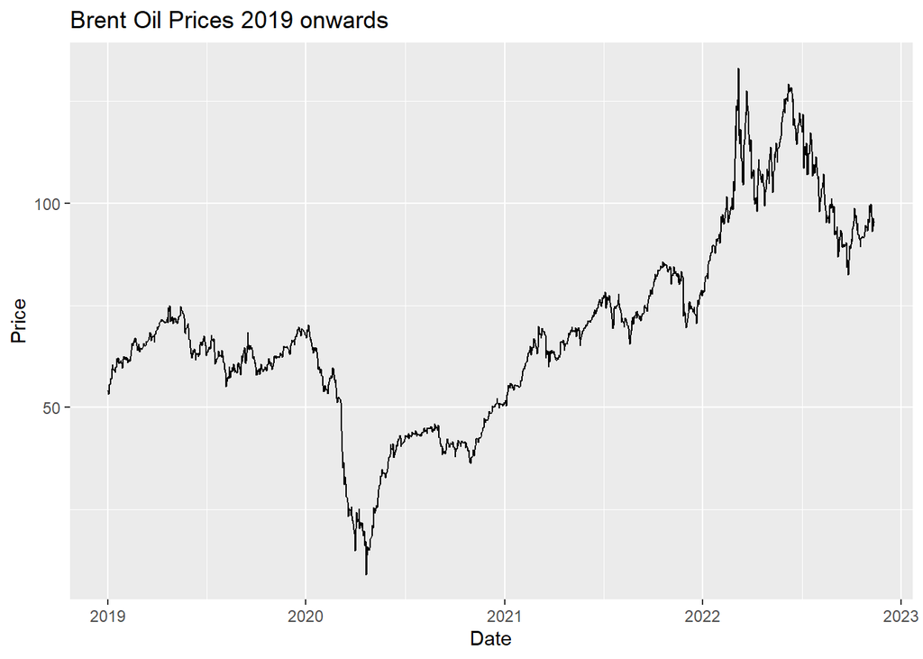

```r
#Price plot
ts_data %>% autoplot(Price) +
  labs(title = "Brent Oil Prices 2019 onwards", x = "Date", y = "Price")
```

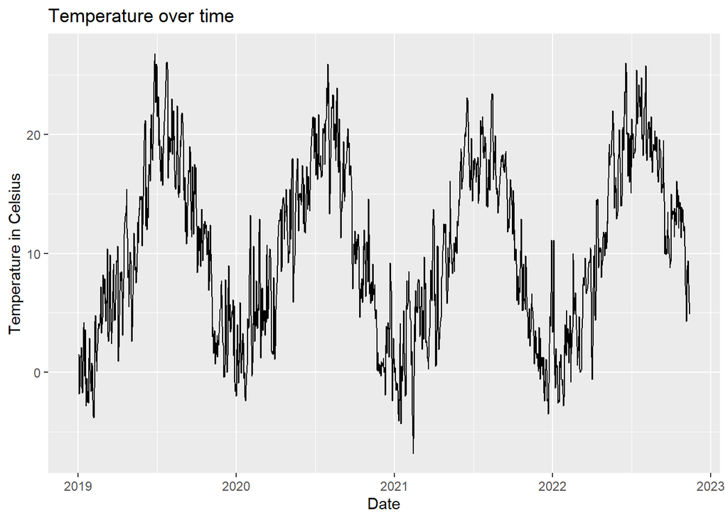

```r
#temp plot
ts_data %>% autoplot(temp) +
  labs(title = "Temperature over time", x = "Date", y = "Temperature in Celsius")
```

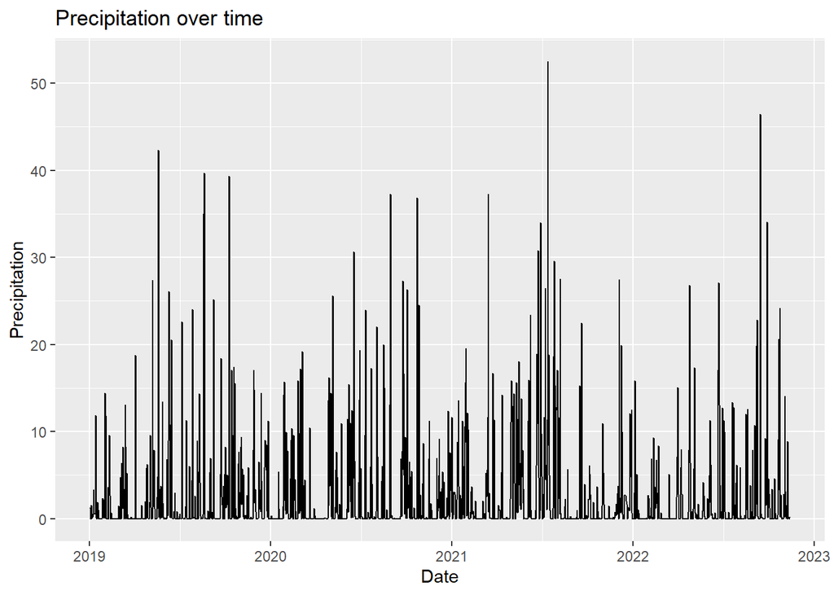

```r
#precip plot
ts_data %>% autoplot(precip) +
  labs(title = "Precipitation over time", x = "Date", y = "Precipitation")
```

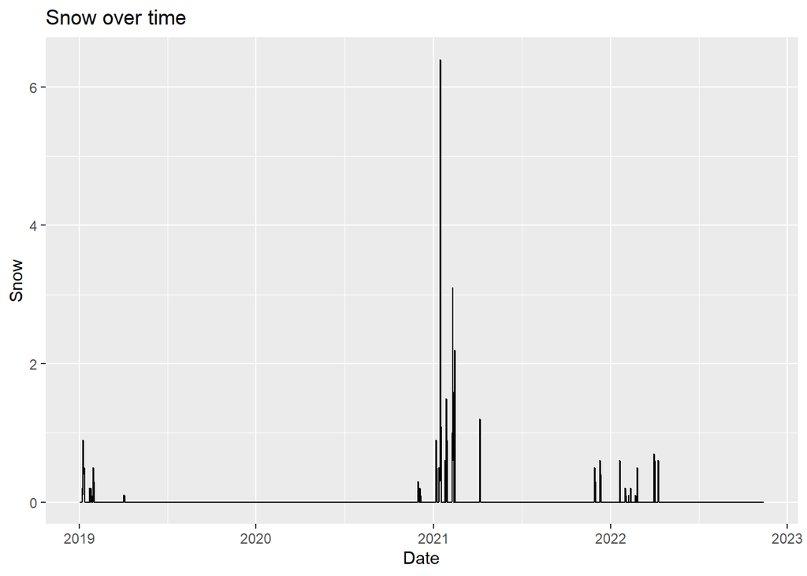

```r
#snow plot
ts_data %>% autoplot(snow) +
  labs(title = "Snow over time", x = "Date", y = "Snow")
```

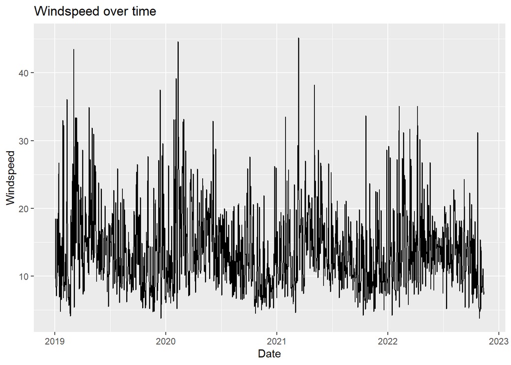

```r
#windspeed plot
ts_data %>% autoplot(windspeed) +
  labs(title = "Windspeed over time", x = "Date", y = "Windspeed")
```

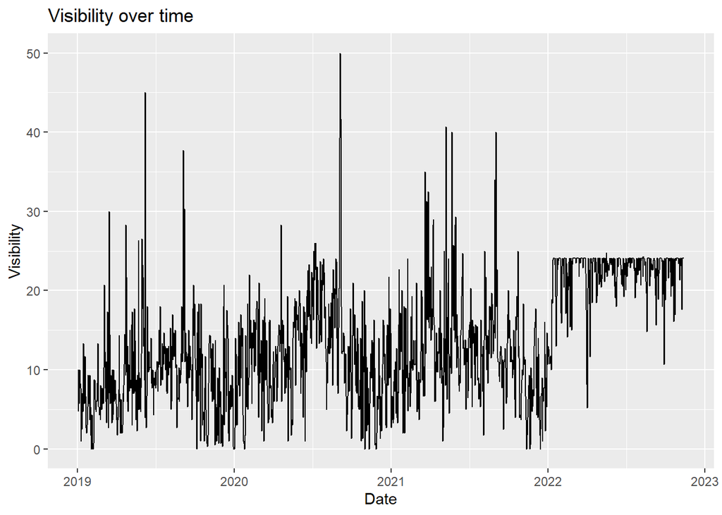

```r
#visibility plot
ts_data %>% autoplot(visibility) +
  labs(title = "Visibility over time", x = "Date", y = "Visibility")
```

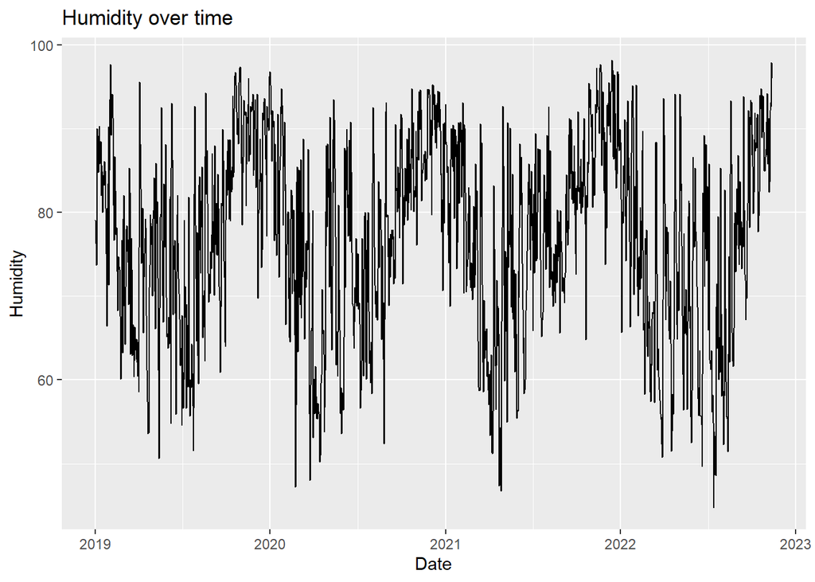

```r
#humidity plot
ts_data %>% autoplot(humidity) +
  labs(title = "Humidity over time", x = "Date", y = "Humidity")
```

### Specific plots for interesting variables

Exploring snow in 2021 - It looks completely unusable because there is too little data.

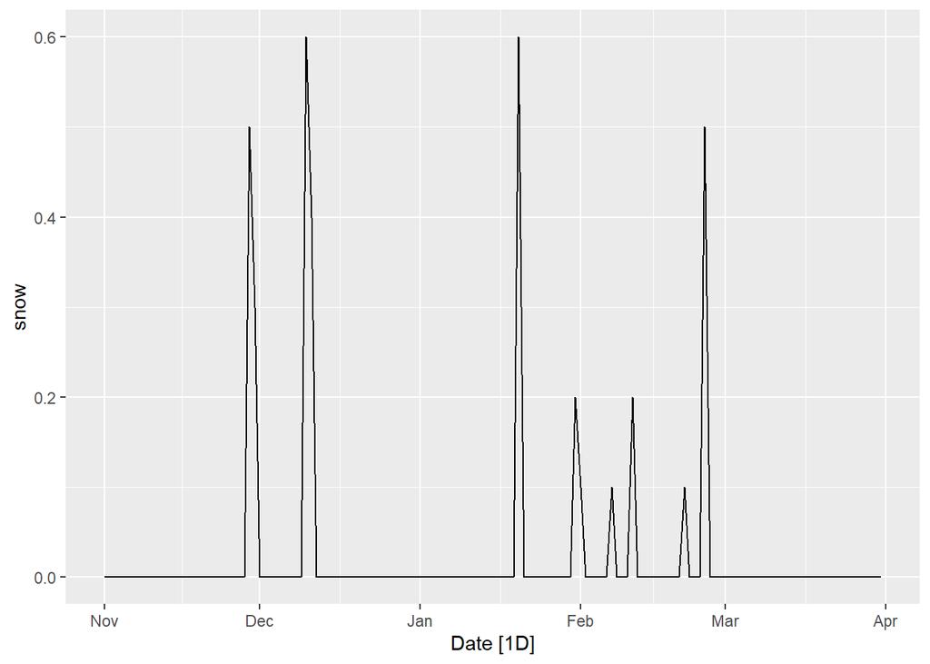

```r
#selecting data from november 2019 until march 2022
ts_data %>%
  filter(Date >= as.Date("2021-11-01") & Date <= as.Date("2022-03-31")) %>%
  autoplot(snow)
```

Now lets look at what’s happening to visibility:

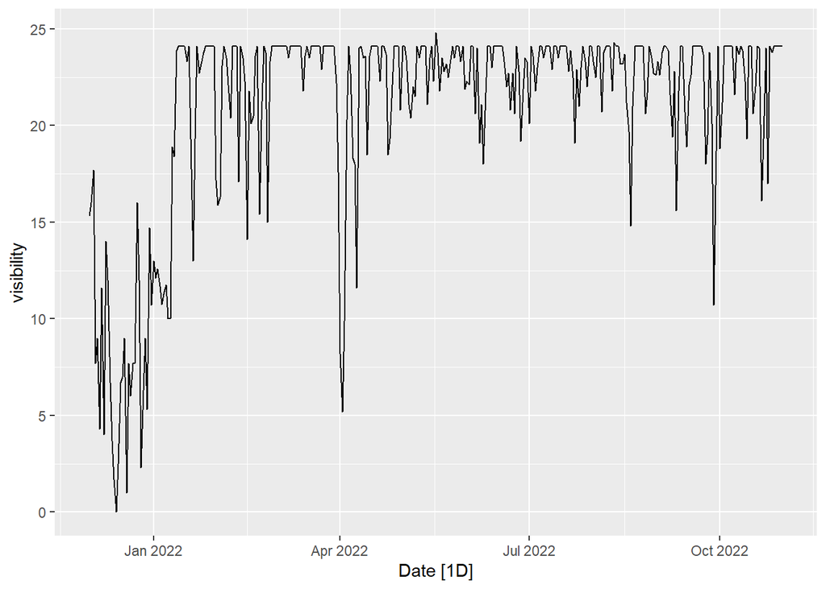

```r
#selecting data from november 2019 until march 2022
ts_data %>%
  filter(Date >= as.Date("2021-12-01") & Date <= as.Date("2022-10-31")) %>%
  autoplot(visibility)
```

This makes absolutely no sense, why is visibility consistently at the same value for almost all of 2022? Did something change in the weather or is this just wrong data? Probably the data is just wrong… If we do decide to use visibility in order to forecast, we will have to stop using visibility before the point where it gets weird (January 2022)

### Decomposition

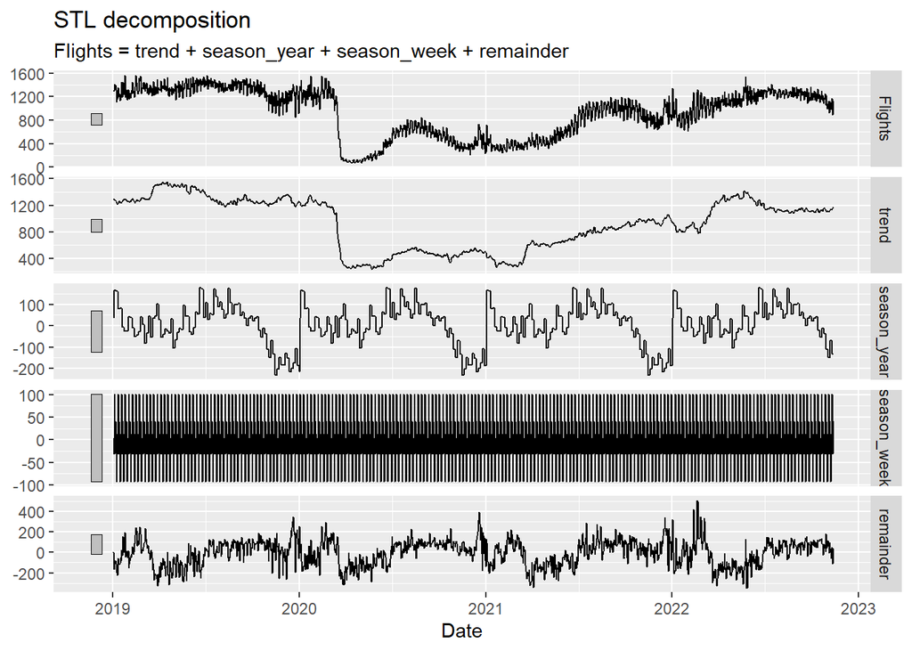

```r
#STL Decomposition for the flights
ts_data %>%
  model(STL(Flights ~ trend(window = 7) + season(window = "periodic"),
    robust = TRUE)) %>%
  components() %>%
  autoplot()
```

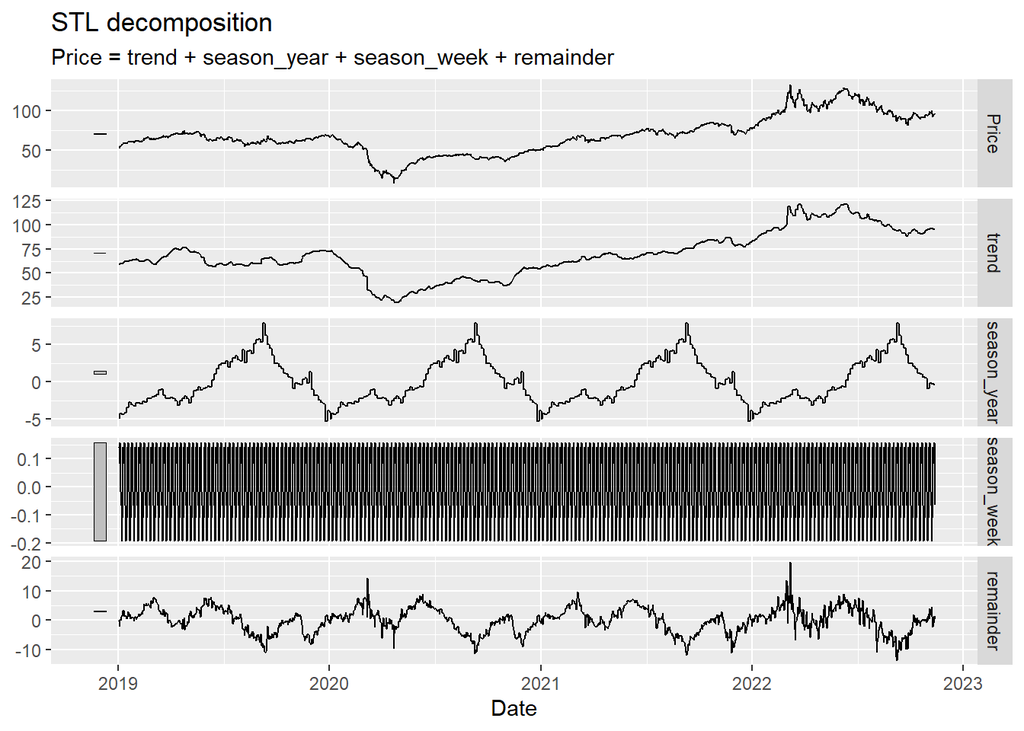

```r
#STL Decomposition for the oil price
ts_data %>%
  model(STL(Price ~ trend(window = 7) + season(window = "periodic"),
    robust = TRUE)) %>%
  components() %>%
  autoplot()
```

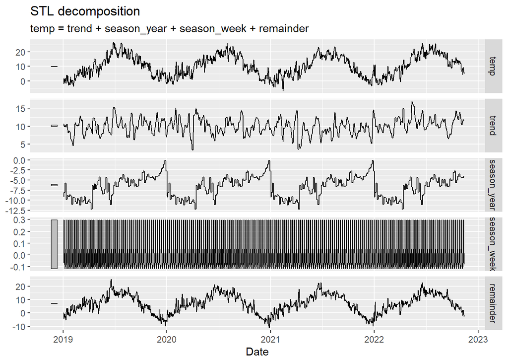

```r
#STL Decomposition for the temperature
ts_data %>%
  model(STL(temp ~ trend(window = 7) + season(window = "periodic"),
    robust = TRUE)) %>%
  components() %>%
  autoplot()
```

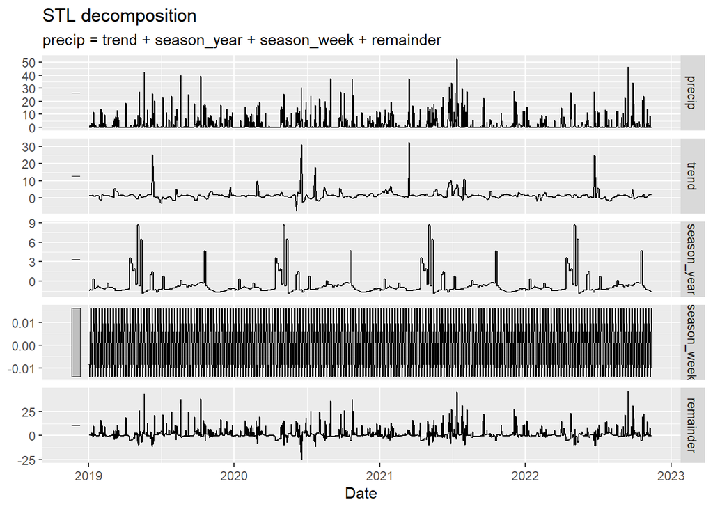

```r
#STL Decomposition for the precip
ts_data %>%
  model(STL(precip ~ trend(window = 7) + season(window = "periodic"),
    robust = TRUE)) %>%
  components() %>%
  autoplot()
```

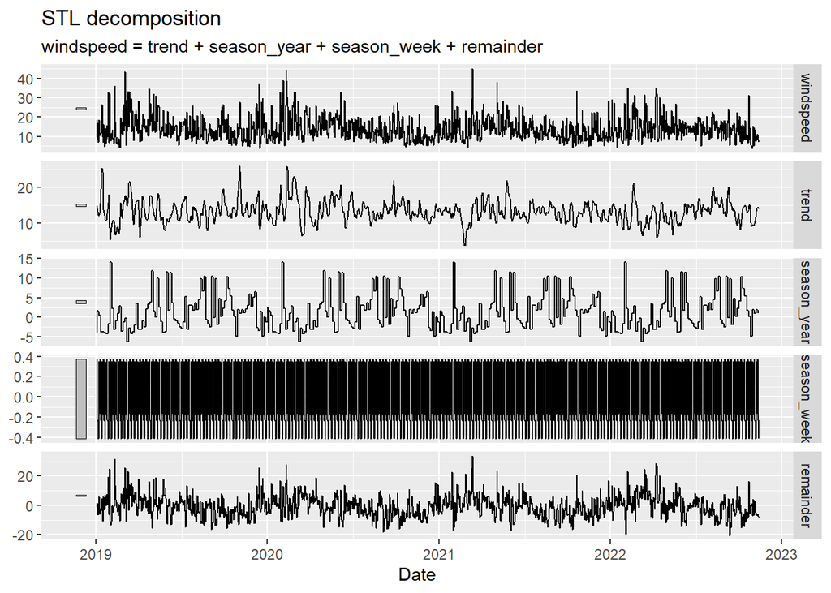

```r
#STL Decomposition for the windspeed
ts_data %>%
  model(STL(windspeed ~ trend(window = 7) + season(window = "periodic"),
    robust = TRUE)) %>%
  components() %>%
  autoplot()
```

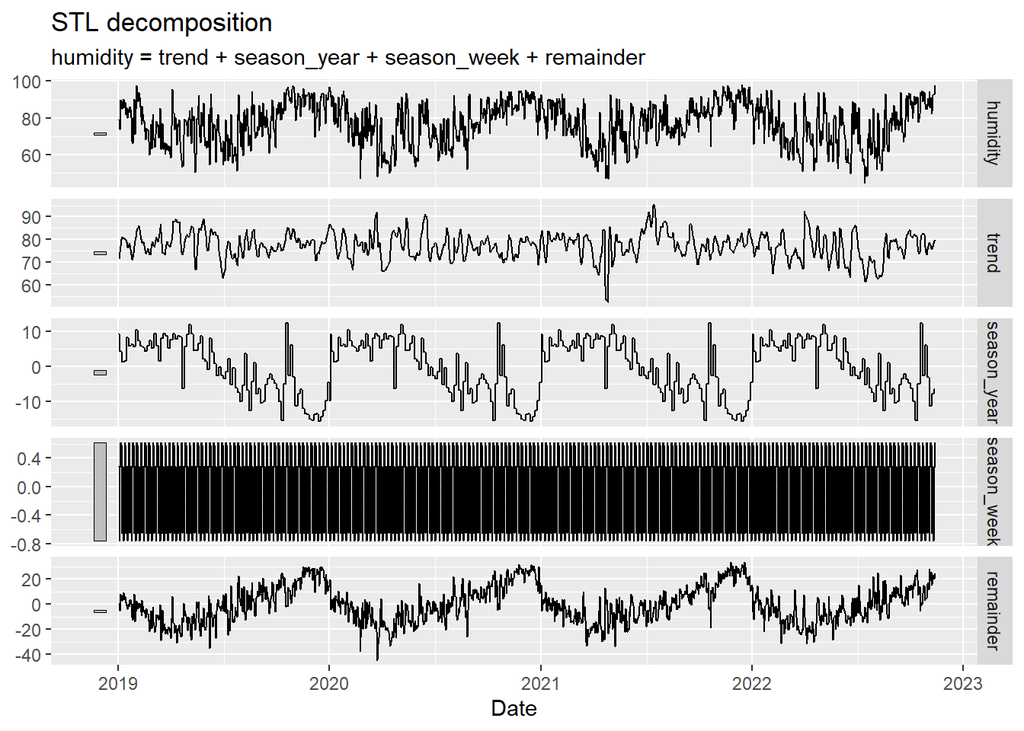

```r
#STL Decomposition for the humidity
ts_data %>%
  model(STL(humidity ~ trend(window = 7) + season(window = "periodic"),
    robust = TRUE)) %>%
  components() %>%
  autoplot()
```